# ANALYSIS OF MONTHLY CRUDE OIL PRICE

Jung-Han Wang, Qing Cai, Yina Wu

# Objective

Analyze and forecast crude oil prices using the data from West Texas Intermediate (WTI)

# Data Preparation

Using *data.table* package to efficiently load csv into R

```r
library(data.table)
gas<-fread("https://www.dropbox.com/s/38awxzkkz1ksmyp/Raw%20Data.csv?raw=1")
```

#### Check the first row of the data. And identify its class.

```r
head(gas)[1,]
```

```
##          DATE VALUE
## 1: 1986-01-02 25.56
```

```r
## Check the format
pandoc.table(apply(gas,2,class))
```

```
##
## -------------------
##   DATE      VALUE
## --------- ---------
## character character
## -------------------
```

- Change DATE format from character to Date
- Changed gas price from character to numeric
- Check all formats are correct

```r
### Change Date format to Date
gas$DATE<-as.Date(gas$DATE)
### Change Value format to Numeric
gas$VALUE<-as.numeric(as.character(gas$VALUE))
## Check all format which looks good, DATE=Date, VALUE=numeric
str(gas)
```

```
## Classes 'data.table' and 'data.frame':   7898 obs. of  2 variables:
##  $ DATE : Date, format: "1986-01-02" "1986-01-03" ...
##  $ VALUE: num  25.6 26 26.5 25.9 25.9 ...
##  - attr(*, ".internal.selfref")=<externalptr>
```

- Remove missing value in gas price
- Calculate monthly average gas price based on daily price

```r
## Remove missing value in the data
gas<-subset(gas,!{is.na(VALUE)})
```

```r
## Get the monthly average
gasMonth<-aggregate(list(monthly_value = gas$VALUE),
                    list(month = cut(gas$DATE, breaks="1 month")),
                    mean)
```

- Convert the data into time series object using function **ts**

```r
## Change Value to TS class
gasMonth_ts<-ts(gasMonth,start=c(1986,1),end=c(2016,4),deltat = 1/12)
gasMonth_ts<-gasMonth_ts[,2] # Remove unnecessary column
head(gasMonth_ts)
```

```
## [1] 22.92545 15.45474 12.61250 12.84364 15.37762 13.42571
```

# ANALYZE TIME SERIES DATA

- Plot the data and the ACF

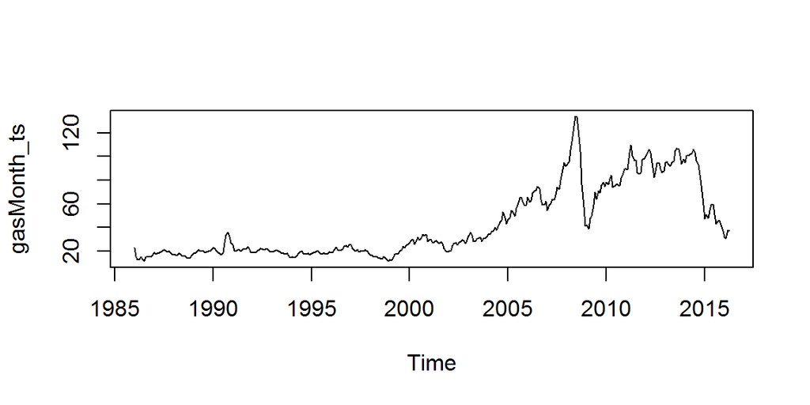

```r
## Plot the original Gas Price
ts.plot(gasMonth_ts)
```

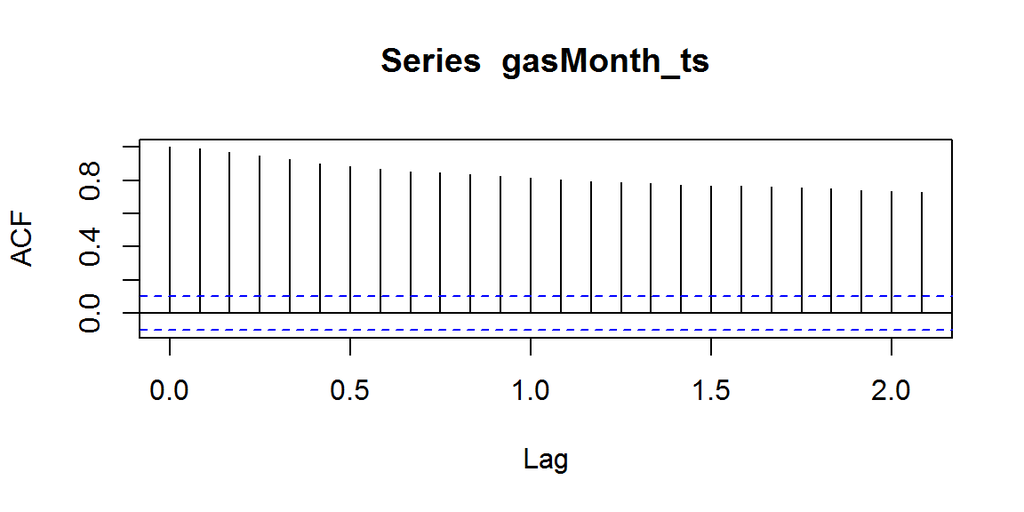

```r
### Plot the acf for the original Gas Price
acf(gasMonth_ts)
```

Check stionarity of the log-difference

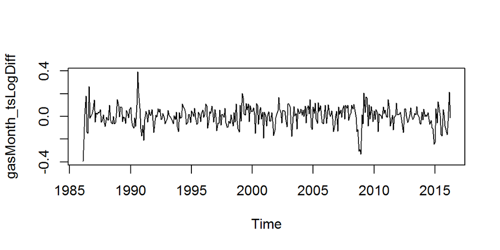

Check acf of the log-difference

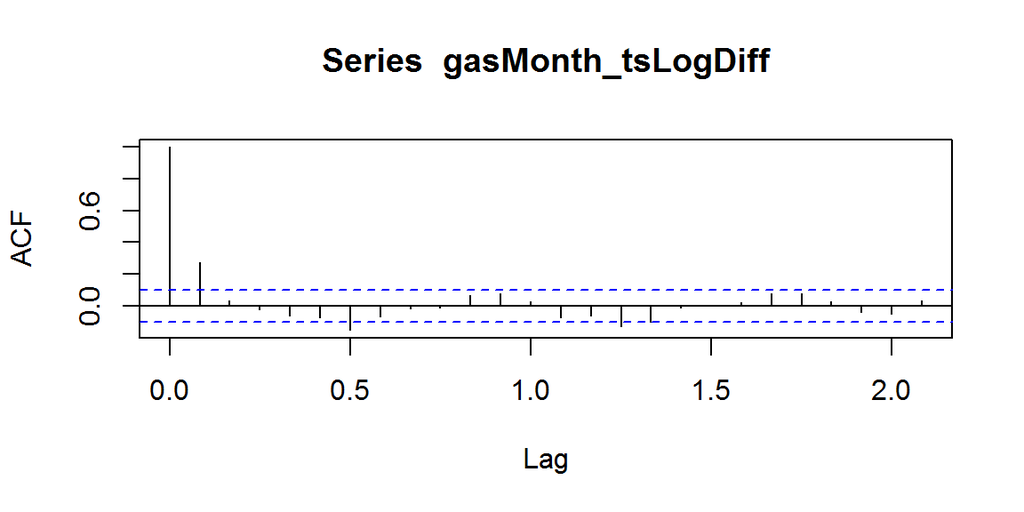

```r
### Plot the acf for the log difference Gas Price
acf(gasMonth_tsLogDiff)
```

Based on AIC, the screening result suggests that an ARMA (1,0) is a better.

```r
#Write a function to compute AIC of various ARMA orders
AICfn<-function(N,K)
{
  for(i in 1:N)
  {for(j in 1:N)
  {
    print(paste("AIC=",round(AIC(arima(K,order=c(i-1,0,j-1))),0),"p=",i-1,"q=", j-1))
  }}}
AICfn(2,gasMonthTrainLogDiff)
```

```
## [1] "AIC= -727 p= 0 q= 0"
## [1] "AIC= -755 p= 0 q= 1"
## [1] "AIC= -756 p= 1 q= 0"
## [1] "AIC= -754 p= 1 q= 1"
```

# RESIDUAL ANALYSIS AND GARCH MODEL

Fit ARMA (1,0) and plot the residual plot.

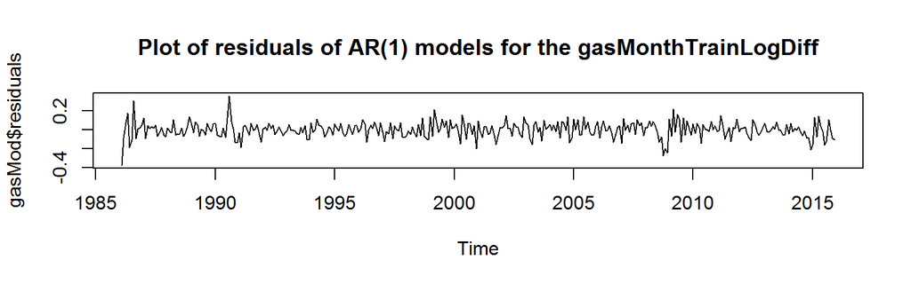

```r
gasMod<-arima(gasMonthTrainLogDiff, order = c(1,0,0));
#Residual analysis
plot(gasMod$residuals,main="Plot of residuals of AR(1) models for the gasMonthTrainLogDiff")
```

Use t-test to find the residual is not different from 0.

```r
## Use t-test to check the value is significantly different from 0
t.test(gasMod$residuals,mu=0)
```

```
##
##  One Sample t-test
##
## data:  gasMod$residuals
## t = 0.086316, df = 358, p-value = 0.9313
## alternative hypothesis: true mean is not equal to 0
## 95 percent confidence interval:
##  -0.008324908  0.009089227
## sample estimates:
##  mean of x
## 0.00038216
```

Check the ACF for squared residuals

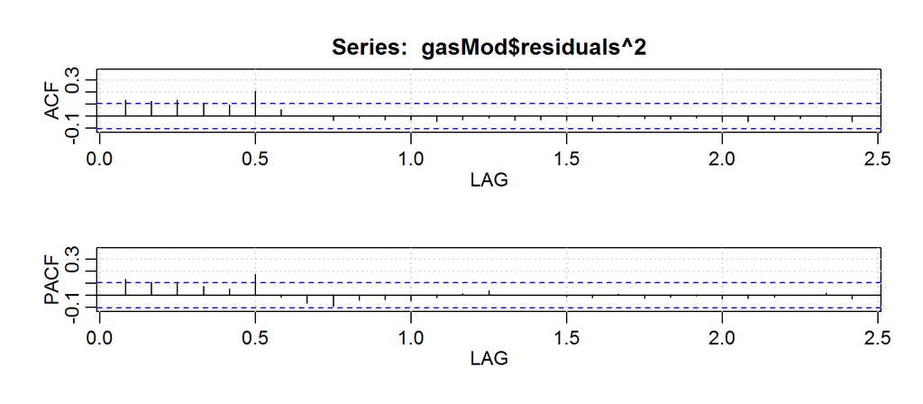

```r
#Residual ACF and PACF plots for squared residuals
acf2(gasMod$residuals^2)
```

Use loop to examine ideal GARCH model which GARCH(1,1) is the best

```r
AICfn2<-function(N,K)
{
  for(i in 1:(N+1))
  { for(j in 1:N)
  {
    print(paste("AIC=",round(AIC(garch(residuals(K),order=c(i,j-1),trace=FALSE)),0),"p=",i,"q=", j-1))
  }}}
AICfn2(2,gasMod)
```

```
## [1] "AIC= -775 p= 1 q= 0"
## [1] "AIC= -809 p= 1 q= 1"
## [1] "AIC= -771 p= 2 q= 0"
## [1] "AIC= -803 p= 2 q= 1"
## [1] "AIC= -767 p= 3 q= 0"
## [1] "AIC= -799 p= 3 q= 1"
```

Fit time series model for ARMA(1,0)+GARCH(1,1)

```r
gfit_garch<-garchFit(formula=~arma(1,0)+garch(1,1),data = gasMonthTrainLogDiff,
               trace = F,include.mean = F)
u <- gfit_garch@sigma.t
```

QQ Plot: ARMA VS ARMA+GARCH

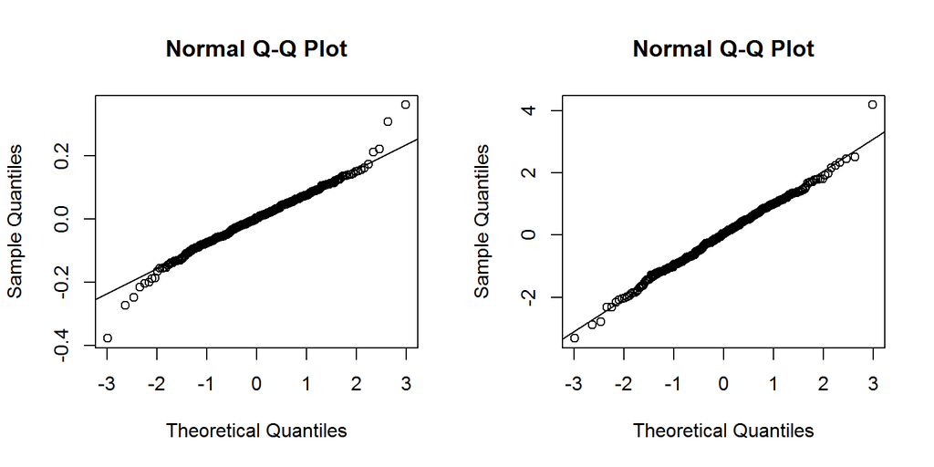

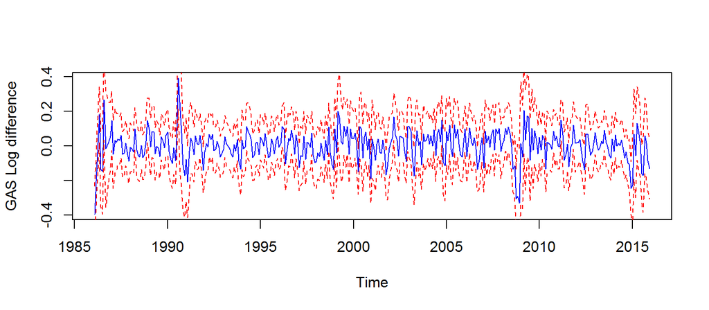

```r
## Plot the garch fit
plot(gasMonthTrainLogDiff, type="l",ylab="GAS Log difference", lwd=1, col="blue")
lines(window(gasMonthTrainLogDiff-2*u), lty=2, col="red")
lines(window(gasMonthTrainLogDiff+2*u), lty=2, col="red")
```

# FIT TIME SERIES NEURAL NETWORK

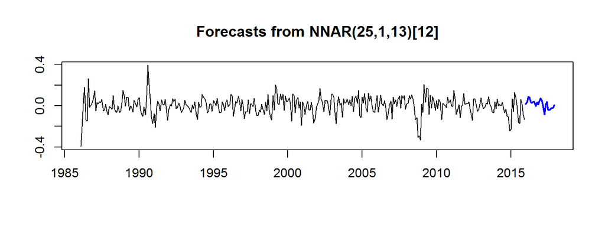

```r
## Fit Neural Network
library(forecast)
neural.fit<-nnetar(gasMonthTrainLogDiff)
neural.fit.for<-forecast(neural.fit)
plot(neural.fit.for)
```

# MODEL COMPARISON

for predicting JAN/2016 - APR/2016

```r
pandoc.table(comparison)
```

|  | GARCH | ARMA | NEURAL NETWORK |
| --- | --- | --- | --- |
| **MAE** | 0.1271 | 0.1254 | 0.125 |
| **RMSE** | 0.09847 | 0.09602 | 0.1195 |